# Les Brioches de Demain - Défi Revitalisation des petites villes

Rasmus Joekaar et Otto de Vandeul

2025-05-05

# Introduction

Dans le cadre du défi autour de la revitalisation des petites villes, développé par l’Open Data University, nous avons choisi comme terrain d’étude la commune de Saint-Brieuc (22278). C’est une commune composée aujourd’hui de près de 44 000 habitants, mais qui a perdu presque 6 000 habitants depuis 1968 (INSEE). Ce recul démographique n’est pas spécifique à Saint-Brieuc et face à ce dernier il existe plusieurs stratégies. La revitalisation des petites villes en est un important. Nous nous sommes intéressés à la présence des commerces en ville, indépendants et issus de grandes chaînes, afin de questionner plusieurs éléments : nos rapports à la consommation, et notamment en ligne, l’aménagement de nos villes face aux défis tels que la revitalisation des centres-villes pour lutter contre la périurbanisation ou bien la ville du quart d’heure. L’objectif de notre travail a été double : essayer de rendre utile les cartes et la représentation d’un territoire sous forme de datavisualisations aux autorités, et aborder la question de la revitalisation des petites villes, en adoptant un angle en particulier.

# Données - Défi : Revitalisation des petites villes

Pour ce faire, nous nous sommes concentrés sur un aspect de Saint-Brieuc : la présence des commerces. Nous avons utilisé les données issues de la Base nationale des commerces recensant les commerces ouverts en 2025. Afin de rendre notre analyse plus fine, nous avons uniquement retenu les supermarchés indépendants et issus de grandes marques, avec pour objectifs de localiser et de créer une typologie de ces commerces. Cela dans le but de produire une étude comparative questionnant l’offre et les habitudes de consommation des habitants et de mieux comprendre la typologie des commerces locaux. L’étude comparative nous a semblé très intéressante pour questionner le développement économique et les perspectives qui en résultent, à savoir comment assurer un développement harmonieux - question qui va de pair avec l’enjeu de revitalisation et de dynamisme autour des petites villes. Bien que Saint-Brieuc s’intègre à Saint-Brieuc Armor Agglomération, l’objectif était d’ici d’intégrer nos données à l’échelle la plus proche des usagers et des projets autour de la revitalisation. C’est pourquoi, nous avons utilisé le découpage administratif communal français d’OpenStreetMap, pour se concentrer uniquement sur les limites administratives de la commune.

# Cartographie et analyse

Utilisant les données mentionnées avant nous arrivons à créer trois carte. Les cartes sont produites grâce à des commandes appartenant à library de sf, dplyr, ggplot2 et ggspatial. Figure 1 est une représentation des supermarchés à Saint-Brieuc qui n’ont pas eu de colonne brand dans les données de BANCO. Il est notable qu’il y a seulement deux supermarchés indépendants, un d’entre eux se situant au centre-ville, et l’autre dans la périphérie.

```r
library (sf)
library (mapsf)
library(ggspatial)
library(ggplot2)
library(dplyr)
```

```r
commune <- st_read("data/communes-20220101.shp", quiet = TRUE)
```

```r
commerce <- st_read("data/data.geojson", quiet = TRUE)
```

```r
stbrieuc <- commerce[commerce$com_insee == "22278", ]
```

```r
stbrieuccom <- commune[commune$insee == "22278", ]
```

```r
commerceok <- st_centroid(stbrieuc)
```

```r
commerceok <- commerceok %>% mutate(geometry = st_cast(geometry, "POINT"))
commerceok$geometry <- st_make_valid(commerceok$geometry)
```

```r
commercedf <- as.data.frame(commerceok)
```

```r
grandecommerce <- commercedf %>% filter(!is.na(brand))
petitecommerce <- commercedf %>% anti_join(grandecommerce, by = "osm_id")
```

```r
grandecommerce <- st_as_sf(grandecommerce)
```

```r
petitecommerce <- st_as_sf(petitecommerce)
```

```r
supermarcheindep <- petitecommerce[petitecommerce$type == "supermarket", ]
```

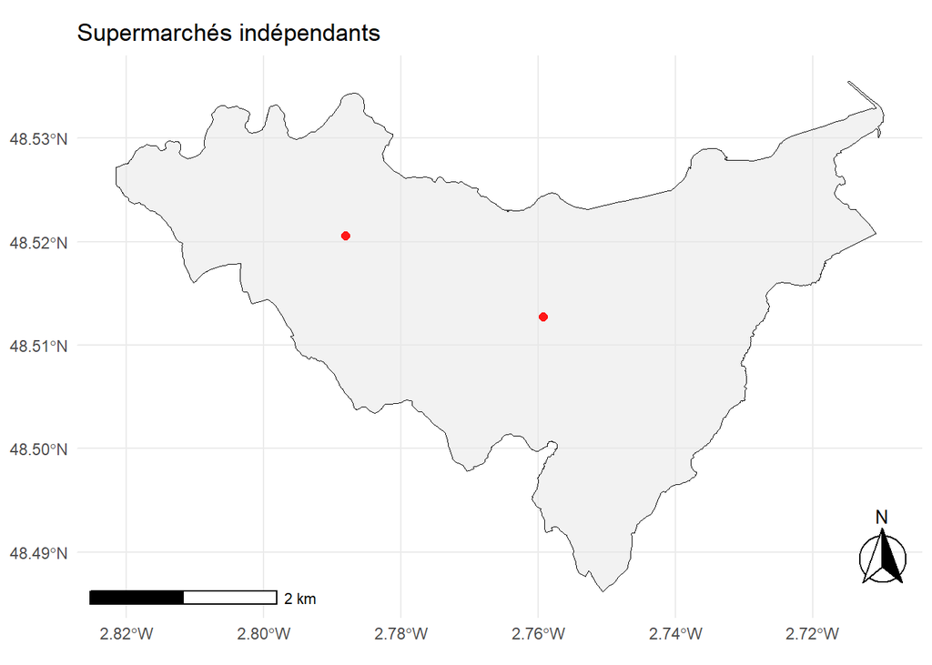

```r
ggplot() +
  geom_sf(data = stbrieuccom, color = "black", size = 0.5, alpha = 0.5) +
  geom_sf(data = supermarcheindep, color = "red", size = 2, alpha = 0.9) +
  annotation_scale(location = "bl", width_hint = 0.3) +
  annotation_north_arrow(location = "br", which_north = "true",
        pad_x = unit(0.0, "in"), pad_y = unit(0.2, "in"),
        style = north_arrow_fancy_orienteering) +
  labs(title = "Supermarchés indépendants",
       fill = "Legend Title") +
  theme_minimal()
```

Figure 1. Les supermarchés indépendants à Saint-Brieuc.

Les supermarchés ayant une marque dans la colonne brand de données de BANCO sont représentés sur la figure 2. Cette fois-ci nous voyons que cette catégorie est plus abondammant présent que cela soit dans le centre-ville ou dans les périphéries. Il faut garder en tête que l’agglomération de Saint-Brieuc s’éteint à des communes adjacentes et donc les grandes marques peuvent y être trouvées aussi.

```r
supermarchechaine <- grandecommerce[grandecommerce$type == "supermarket", ]
```

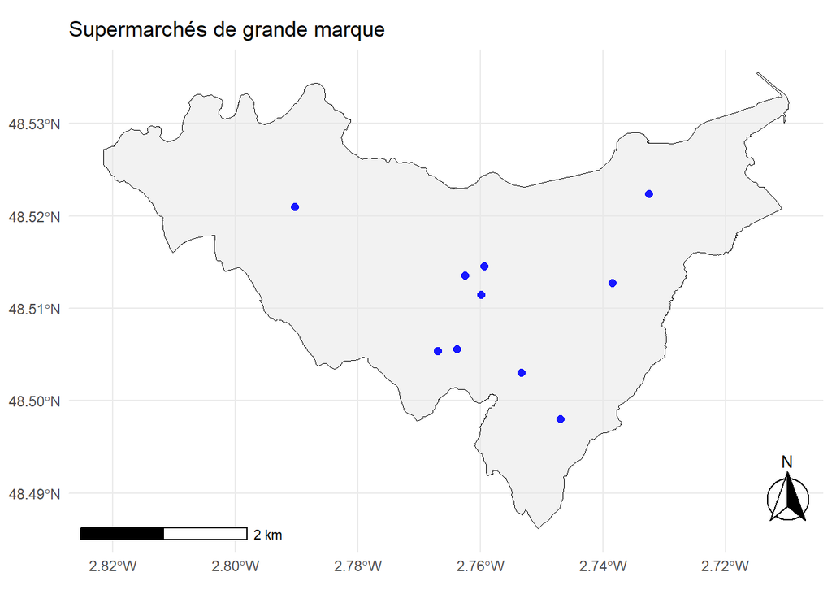

```r
ggplot() +
  geom_sf(data = stbrieuccom, color = "black", size = 0.5, alpha = 0.5) +
  geom_sf(data = supermarchechaine, color = "blue", size = 2, alpha = 0.9) +
  annotation_scale(location = "bl", width_hint = 0.3) +
  annotation_north_arrow(location = "br", which_north = "true",
        pad_x = unit(0.0, "in"), pad_y = unit(0.2, "in"),
        style = north_arrow_fancy_orienteering) +
  labs(title = "Supermarchés de grande marque",
       fill = "Legend Title") +
  theme_minimal()
```

Figure 2. Les supermarchés de grande marque à Saint-Brieuc.

Enfin figure 3 joint les deux figures d’avant et il devient remarquable que les périphéries en totale abritent plus de supermarchés que le centre-ville historique. Cette ville tout à fait vit une tendance où les commerces se déplacent hors du centre pour être plus accessibles par la voierie. Ce processus augmente la popularité des commerces hors centre et alors aggrave la situation davantage.

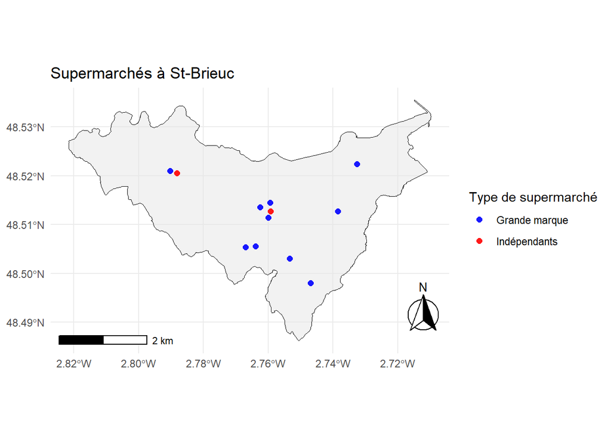

```r
p <- ggplot() +
  geom_sf(data = stbrieuccom, color = "black", size = 0.5, alpha = 0.5) +
  geom_sf(data = supermarcheindep, aes(color = "Indépendants"), size = 2, alpha = 0.9) +
  geom_sf(data = supermarchechaine, aes(color = "Grande marque"), size = 2, alpha = 0.9) +
  scale_color_manual(name = "Type de supermarché", values = c("Indépendants" = "red", "Grande marque" = "blue")) +
  annotation_scale(location = "bl", width_hint = 0.3) +
  annotation_north_arrow(location = "br", which_north = "true",
        pad_x = unit(0.0, "in"), pad_y = unit(0.2, "in"),
        style = north_arrow_fancy_orienteering) +
  labs(title = "Supermarchés à St-Brieuc") +
  theme_minimal()

print(p)
```

Figure 3. Les supermarchés à Saint-Brieuc.

```r
ggsave("supermarches_st_brieuc.png", plot = p, width = 10, height = 8)
```

# Conclusion

L’étude sur la revitalisation de la commune de Saint-Brieuc, menée dans le cadre du défi de l’Open Data University, met en lumière plusieurs enjeux cruciaux liés à la dynamique des petites villes. En se concentrant sur la présence des commerces, notamment les supermarchés indépendants et ceux issus de grandes chaînes, l’analyse révèle des tendances significatives sur la répartition des commerces. Cette étude souligne l’importance de comprendre la typologie des commerces locaux et leurs impacts. Elle met en évidence la nécessité de stratégies ciblées pour revitaliser les centres-villes et promouvoir un développement harmonieux, en intégrant des perspectives telles que la “ville du quart d’heure” pour améliorer la qualité de vie des habitants. Pour contrer ces tendances, il est crucial d’arrêter la périurbanisation et la dépendance à la voiture. En favorisant des politiques qui encouragent le retour des commerces au centre-ville et en améliorant les infrastructures piétonnes et cyclables, Saint-Brieuc pourra retrouver une dynamique et une attractivité accrus, tout en répondant aux défis contemporains de la mobilité durable.